# Self-Driving Car Engineer Nanodegree

## Project: Build a Traffic Sign Recognition Classifier

In this notebook, a template is provided for you to implement your functionality in stages, which is required to successfully complete this project. If additional code is required that cannot be included in the notebook, be sure that the Python code is successfully imported and included in your submission if necessary.

In addition to implementing code, there is a writeup to complete. The writeup should be completed in a separate file, which can be either a markdown file or a pdf document. There is a [write up template](https://github.com/udacity/CarND-Traffic-Sign-Classifier-Project/blob/master/writeup_template.md) that can be used to guide the writing process. Completing the code template and writeup template will cover all of the [rubric points](https://review.udacity.com/#!/rubrics/481/view) for this project.

The [rubric](https://review.udacity.com/#!/rubrics/481/view) contains "Stand Out Suggestions" for enhancing the project beyond the minimum requirements. The stand out suggestions are optional. If you decide to pursue the "stand out suggestions", you can include the code in this Ipython notebook and also discuss the results in the writeup file.

> **Note:** Code and Markdown cells can be executed using the **Shift + Enter** keyboard shortcut. In addition, Markdown cells can be edited by typically double-clicking the cell to enter edit mode.

## Step 0: Load The Data

```python
# Load pickled data
import pickle

# TODO: Fill this in based on where you saved the training and testing data

training_file = './traffic-signs-data/train.p'
validation_file= './traffic-signs-data/valid.p'
testing_file = './traffic-signs-data/test.p'

with open(training_file, mode='rb') as f:
    train = pickle.load(f)
with open(validation_file, mode='rb') as f:
    valid = pickle.load(f)
with open(testing_file, mode='rb') as f:
    test = pickle.load(f)

X_train_init, y_train = train['features'], train['labels']
X_valid_init, y_valid = valid['features'], valid['labels']
X_test_init, y_test = test['features'], test['labels']
```

## Step 1: Dataset Summary & Exploration

The pickled data is a dictionary with 4 key/value pairs:

- `'features'` is a 4D array containing raw pixel data of the traffic sign images, (num examples, width, height, channels).
- `'labels'` is a 1D array containing the label/class id of the traffic sign. The file `signnames.csv` contains id -> name mappings for each id.
- `'sizes'` is a list containing tuples, (width, height) representing the original width and height the image.
- `'coords'` is a list containing tuples, (x1, y1, x2, y2) representing coordinates of a bounding box around the sign in the image. **THESE COORDINATES ASSUME THE ORIGINAL IMAGE. THE PICKLED DATA CONTAINS RESIZED VERSIONS (32 by 32) OF THESE IMAGES**

Complete the basic data summary below. Use python, numpy and/or pandas methods to calculate the data summary rather than hard coding the results. For example, the [pandas shape method](http://pandas.pydata.org/pandas-docs/stable/generated/pandas.DataFrame.shape.html) might be useful for calculating some of the summary results.

### Provide a Basic Summary of the Data Set Using Python, Numpy and/or Pandas

```python
### Replace each question mark with the appropriate value.
### Use python, pandas or numpy methods rather than hard coding the results
import numpy as np

# TODO: Number of training examples
n_train = len(X_train_init)
n_valid = len(X_valid_init)

# TODO: Number of testing examples.
n_test = len(X_test_init)

# TODO: What's the shape of an traffic sign image?
image_shape = X_train_init[0].shape

# TODO: How many unique classes/labels there are in the dataset.
n_classes = len(np.unique(y_train))

assert(len(X_train_init) == len(y_train))
assert(len(X_valid_init) == len(y_valid))
assert(len(X_test_init) == len(y_test))

print("Number of training examples =", n_train)
print("Number of valid examples =", n_valid)
print("Number of testing examples =", n_test)
print("Image data shape =", image_shape)
print("Number of classes =", n_classes)
```

```
Number of training examples = 34799
Number of valid examples = 4410
Number of testing examples = 12630
Image data shape = (32, 32, 3)
Number of classes = 43
```

### Include an exploratory visualization of the dataset

Visualize the German Traffic Signs Dataset using the pickled file(s). This is open ended, suggestions include: plotting traffic sign images, plotting the count of each sign, etc.

The [Matplotlib](http://matplotlib.org/) [examples](http://matplotlib.org/examples/index.html) and [gallery](http://matplotlib.org/gallery.html) pages are a great resource for doing visualizations in Python.

**NOTE:** It's recommended you start with something simple first. If you wish to do more, come back to it after you've completed the rest of the sections.

```
Labels:
[[ 25.  25.  13.  11.  11.  12.  25.  26.]
 [ 39.  12.   2.  38.  17.  13.  39.   1.]
 [  1.  38.  12.  13.  23.  11.   1.  10.]
 [ 12.  32.  11.   8.  10.   9.  17.   7.]
 [ 30.   5.  10.   1.  14.   3.   2.  36.]
 [ 28.  11.   3.  13.  10.  13.   2.  28.]
 [ 16.  23.   9.  18.  12.   2.  31.  12.]
 [  7.   7.   4.  20.   1.  27.  26.   2.]]
```

[figure not shown]

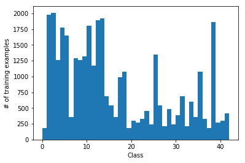

```python
### Data exploration visualization code goes here.
### Feel free to use as many code cells as needed.
import matplotlib.pyplot as plt
# Visualizations will be shown in the notebook.
%matplotlib inline

#Plot a matrix of images
col=8
row=8
fig, axes = plt.subplots(figsize=[12.0, 12.0], ncols=col, nrows=row)
list_labels = np.zeros((col,row))
for i in range(col):
    for j in range(row):
        index = np.random.randint(0, len(X_train_init))
        image = X_train_init[index].squeeze()
        axes[i, j].imshow(image)
        list_labels[i,j] = y_train[index]

print("Labels: ")
print(list_labels)

plt.show()
#Plot histogram of labels
plt.hist(y_train, bins=np.arange(y_train.min(), y_train.max()+1))
plt.xlabel('Class')
plt.ylabel('# of training examples')
```

## Step 2: Design and Test a Model Architecture

Design and implement a deep learning model that learns to recognize traffic signs. Train and test your model on the [German Traffic Sign Dataset](http://benchmark.ini.rub.de/?section=gtsrb&subsection=dataset).

The LeNet-5 implementation shown in the classroom at the end of the CNN lesson is a solid starting point. You'll have to change the number of classes and possibly the preprocessing, but aside from that it's plug and play!

With the LeNet-5 solution from the lecture, you should expect a validation set accuracy of about 0.89. To meet specifications, the validation set accuracy will need to be at least 0.93. It is possible to get an even higher accuracy, but 0.93 is the minimum for a successful project submission.

There are various aspects to consider when thinking about this problem:

- Neural network architecture (is the network over or underfitting?)
- Play around preprocessing techniques (normalization, rgb to grayscale, etc)
- Number of examples per label (some have more than others).
- Generate fake data.

Here is an example of a [published baseline model on this problem](http://yann.lecun.com/exdb/publis/pdf/sermanet-ijcnn-11.pdf). It's not required to be familiar with the approach used in the paper but, it's good practice to try to read papers like these.

### Pre-process the Data Set (normalization, grayscale, etc.)

Use the code cell (or multiple code cells, if necessary) to implement the first step of your project.

```python
import tensorflow as tf
from sklearn.preprocessing import LabelBinarizer
import numpy as np
from matplotlib.colors import rgb_to_hsv
import matplotlib.pyplot as plt
#import image as imagelib

from skimage import data, io, filters, color, util, exposure
from skimage.color.adapt_rgb import adapt_rgb, each_channel, hsv_value
from skimage.filters import rank
from skimage.morphology import disk
from skimage.color.adapt_rgb import adapt_rgb, each_channel, hsv_value


@adapt_rgb(each_channel)
def sobel_each(image):
    return filters.sobel(image)


@adapt_rgb(hsv_value)
def sobel_hsv(image):
    return filters.sobel(image)

#import cv2

#Normalize
def normalize(x):
    """
    Normalize a list of sample image data in the range of 0 to 1
    : x: List of image data.  The image shape is (32, 32, 3)
    : return: Numpy array of normalize data
    """
    return (x / 255.0).astype(np.float32)

#Using cv2
def cv2_rgb_to_hsv (images):
    hsv = []
    for img in images:
        hsv.append = cv2.cvtColor(img, cv2.COLOR_RGB2HSV)
    return hsv

#Using tf
def tf_rgb_to_hsv(images):
    tensor_imgs = tf.image.rgb_to_hsv(images)
    x = tf.contrib.util.make_ndarray(tensor_imgs)
    return x


#Using %matplotlib
def rgb2hsv(images):
    '''
    matplotlib.colors.rgb_to_hsv(arr)
    convert float rgb values (in the range [0, 1]), in a numpy array to hsv values.
    Parameters:
    arr : (..., 3) array-like All values must be in the range [0, 1]
    Returns: hsv : (..., 3) ndarray Colors converted to hsv values in range [0, 1]
    '''
    return rgb_to_hsv(images)

def preprocessing(imgs):
    imgs = color.rgb2grey(imgs)
    imgs = exposure.equalize_adapthist(imgs)
    return imgs
```

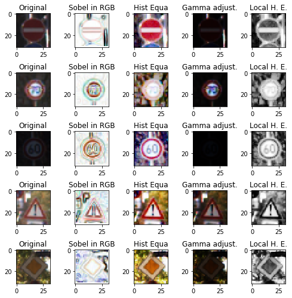

```python
### Data exploration visualization code goes here.
### Feel free to use as many code cells as needed.
##TEST 3
col=5
row=5
fig, axes = plt.subplots(figsize=[7.0, 7.0], ncols=col, nrows=row)
fig.tight_layout()
list_labels = np.zeros((col,row))
for i in range(row):
    index = np.random.randint(0, len(X_train_init))
    image = X_train_init[index].squeeze()
    #Original image
    axes[i, 0].imshow(image)
    axes[i, 0].set_title("Original")
    #processed image
    #image1 = color.rgb2gray(image)
    image1 = sobel_each(image)
    image1 = exposure.rescale_intensity(1 - image1)
    axes[i, 1].imshow(image1, cmap="gray")
    axes[i, 1].set_title("Sobel in RGB")
    #processed image
    image2 = exposure.equalize_hist(image)
    axes[i, 2].imshow(image2)
    axes[i, 2].set_title("Hist Equa")
     #processed image
    image3 = exposure.adjust_gamma(image, 2)
    axes[i, 3].imshow(image3)
    axes[i, 3].set_title("Gamma adjust.")
     #processed image
    selem = disk(30)
    image4 = rank.equalize(color.rgb2gray(image),selem=selem)
    axes[i, 4].imshow(image4,cmap="gray")
    axes[i, 4].set_title("Local H. E.")
```

```python
#Data Augmentation
#code from: http://navoshta.com/traffic-signs-classification/
import numpy as np
import sys
import time

def flip_extend(X, y):
    # Classes of signs that, when flipped horizontally, should still be classified as the same class
    self_flippable_horizontally = np.array([11, 12, 13, 15, 17, 18, 22, 26, 30, 35])
    # Classes of signs that, when flipped vertically, should still be classified as the same class
    self_flippable_vertically = np.array([1, 5, 12, 15, 17])
    # Classes of signs that, when flipped horizontally and then vertically, should still be classified as the same class
    self_flippable_both = np.array([32, 40])
    # Classes of signs that, when flipped horizontally, would still be meaningful, but should be classified as some other class
    cross_flippable = np.array([
        [19, 20],
        [33, 34],
        [36, 37],
        [38, 39],
        [20, 19],
        [34, 33],
        [37, 36],
        [39, 38],
    ])
    num_classes = 43

    X_extended = np.empty([0, X.shape[1], X.shape[2], X.shape[3]], dtype = X.dtype)
    y_extended = np.empty([0], dtype = y.dtype)

    for c in range(num_classes):
        # First copy existing data for this class
        X_extended = np.append(X_extended, X[y == c], axis = 0)
        # If we can flip images of this class horizontally and they would still belong to said class...
        if c in self_flippable_horizontally:
            # ...Copy their flipped versions into extended array.
            X_extended = np.append(X_extended, X[y == c][:, :, ::-1, :], axis = 0)
        # If we can flip images of this class horizontally and they would belong to other class...
        if c in cross_flippable[:, 0]:
            # ...Copy flipped images of that other class to the extended array.
            flip_class = cross_flippable[cross_flippable[:, 0] == c][0][1]
            X_extended = np.append(X_extended, X[y == flip_class][:, :, ::-1, :], axis = 0)
        # Fill labels for added images set to current class.
        y_extended = np.append(y_extended, np.full((X_extended.shape[0] - y_extended.shape[0]), c, dtype = int))

        # If we can flip images of this class vertically and they would still belong to said class...
        if c in self_flippable_vertically:
            # ...Copy their flipped versions into extended array.
            X_extended = np.append(X_extended, X_extended[y_extended == c][:, ::-1, :, :], axis = 0)
        # Fill labels for added images set to current class.
        y_extended = np.append(y_extended, np.full((X_extended.shape[0] - y_extended.shape[0]), c, dtype = int))

        # If we can flip images of this class horizontally AND vertically and they would still belong to said class...
        if c in self_flippable_both:
            # ...Copy their flipped versions into extended array.
            X_extended = np.append(X_extended, X_extended[y_extended == c][:, ::-1, ::-1, :], axis = 0)
        # Fill labels for added images set to current class.
        y_extended = np.append(y_extended, np.full((X_extended.shape[0] - y_extended.shape[0]), c, dtype = int))

    return (X_extended, y_extended)

# Print iterations progress
def print_progress(iteration, total):
    """
    Call in a loop to create terminal progress bar

    Parameters
    ----------

    iteration :
                Current iteration (Int)
    total     :
                Total iterations (Int)
    """
    str_format = "{0:.0f}"
    percents = str_format.format(100 * (iteration / float(total)))
    filled_length = int(round(100 * iteration / float(total)))
    bar = '█' * filled_length + '-' * (100 - filled_length)

    sys.stdout.write('\r |%s| %s%%' % (bar, percents)),

    if iteration == total:
        sys.stdout.write('\n')
    sys.stdout.flush()
```

```python
X_train_ext, y_train_ext = flip_extend(X_train_init, y_train)
X_valid_ext, y_valid_ext = flip_extend(X_valid_init, y_valid)
X_test_ext, y_test_ext = flip_extend(X_test_init, y_test)
```

```python
##Balance of DATASET
#http://datascience.stackexchange.com/questions/13490/how-to-set-class-weights-for-imbalanced-classes-in-keras
#https://github.com/fchollet/keras/issues/1875
#https://github.com/scikit-learn/scikit-learn/blob/master/sklearn/utils/class_weight.py
from collections import Counter


def get_class_weights(y):
    counter = Counter(y)
    majority = max(counter.values())
    return  {cls: float(majority/count) for cls, count in counter.items()}

class_weight  = get_class_weights(y_train)
print(class_weight)
```

```
{0: 11.166666666666666, 1: 1.0151515151515151, 2: 1.0, 3: 1.5952380952380953, 4: 1.1355932203389831, 5: 1.2181818181818183, 6: 5.583333333333333, 7: 1.558139534883721, 8: 1.5952380952380953, 9: 1.5227272727272727, 10: 1.1166666666666667, 11: 1.7179487179487178, 12: 1.0634920634920635, 13: 1.046875, …
```

```python
### Preprocess the data here. Preprocessing steps could include normalization, converting to grayscale, etc.
### Feel free to use as many code cells as needed.
import numpy as np
from skimage import color, util, exposure
import warnings

#import cv2

#Normalize
def normalize(x):
    """
    Normalize a list of sample image data in the range of 0 to 1
    : x: List of image data.  The image shape is (32, 32, 3)
    : return: Numpy array of normalize data
    """
    return (x / 255.0).astype(np.float32)

def rgb2grey(x):
    return color.rgb2grey(x)

#http://scikit-image.org/docs/dev/auto_examples/color_exposure/plot_equalize.html#sphx-glr-auto-examples-color-exposure-plot-equalize-py
#http://scikit-image.org/docs/dev/api/skimage.exposure.html#skimage.exposure.equalize_hist
def preprocessing(x):
    x = exposure.equalize_hist(x)
    return x

def preprocessing2(X):
    #Convert to grayscale, e.g. single channel Y
    X = rgb2grey(X)
    #Scale features to be in [0, 1]

    for i in range(X.shape[0]):
        with warnings.catch_warnings():
            warnings.simplefilter("ignore")
            X[i] = exposure.equalize_adapthist(X[i])
        print_progress(i + 1, X.shape[0])
    return X

if(False):
    print(X_train_init[0].shape)

    X_train = preprocessing2(X_train_ext)
    X_valid = preprocessing2(X_valid_ext)
    X_test = preprocessing2(X_test_ext)

    print(X_train[0].shape)
```

```python
import pickle

if(False):
    training_file = './traffic-signs-data/train_pp.p'
    validation_file= './traffic-signs-data/valid_pp.p'
    testing_file = './traffic-signs-data/test_pp.p'


    pickle.dump({
            "features" : X_train,
            "labels" : y_train_ext
        }, open(training_file, "wb" ) )
    print("Preprocessed dataset saved in", training_file)

    pickle.dump({
            "features" : X_valid,
            "labels" : y_valid_ext
        }, open(validation_file, "wb" ) )
    print("Preprocessed dataset saved in", validation_file)

    pickle.dump({
            "features" : X_test,
            "labels" : y_test_ext
        }, open(testing_file, "wb" ) )
    print("Preprocessed dataset saved in", testing_file)

    print("Preprocessed dataset saved in", training_file)
    print("Preprocessed dataset saved in", validation_file)
    print("Preprocessed dataset saved in", testing_file)
```

```python
# Load pickled data
import pickle

# TODO: Fill this in based on where you saved the training and testing data

training_file = './traffic-signs-data/train_pp.p'
validation_file= './traffic-signs-data/valid_pp.p'
testing_file = './traffic-signs-data/test_pp.p'

with open(training_file, mode='rb') as f:
    train = pickle.load(f)
with open(validation_file, mode='rb') as f:
    valid = pickle.load(f)
with open(testing_file, mode='rb') as f:
    test = pickle.load(f)

X_train, y_train = train['features'], train['labels']
X_valid, y_valid = valid['features'], valid['labels']
X_test, y_test = test['features'], test['labels']
```

```python
X_train = X_train.reshape((X_train.shape[0],X_train.shape[1],X_train.shape[2],1))
X_valid = X_valid.reshape((X_valid.shape[0],X_valid.shape[1],X_valid.shape[2],1))
X_test = X_test.reshape((X_test.shape[0],X_test.shape[1],X_test.shape[2],1))

print(X_train[0].shape)
```

```
(32, 32, 1)
```

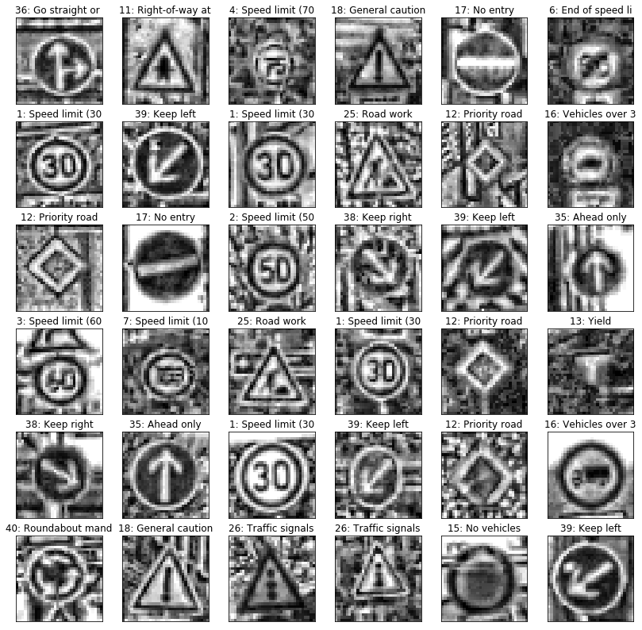

```python
### Data exploration visualization code goes here.
### Feel free to use as many code cells as needed.
import numpy as np
import matplotlib.pyplot as plt
from pandas.io.parsers import read_csv
# Visualizations will be shown in the notebook.
%matplotlib inline

csv_names = read_csv("signnames.csv").values[:, 1]
#Plot a matrix of images
row=6
col=6
fig, axes = plt.subplots(figsize=[14.0, 14.0], ncols=col, nrows=row)
list_labels = np.zeros((col,row))
for i in range(row):
    for j in range(0, col, 1):
        #Preprocessed Image
        index = np.random.randint(0, len(X_train))
        label = y_train[index]
        csv_name = csv_names[label]
        sign_code = str(label)+ ": " + csv_name[:15]
        image = X_train[index].squeeze()
        axes[i, j].imshow(image,cmap="gray")
        axes[i, j].set_title(sign_code)
        axes[i, j].set_xticks([])
        axes[i, j].set_yticks([])
```

```python
#One-hot encode
from sklearn.preprocessing import LabelBinarizer
n_classes = len(np.unique(y_train))
encoder = LabelBinarizer()
labels = np.arange(n_classes)
encoder.fit(labels)

def one_hot_encode(x):
    """
    One hot encode a list of sample labels. Return a one-hot encoded vector for each label.
    : x: List of sample Labels
    : return: Numpy array of one-hot encoded labels
    """
    # TODO: Implement Function
    out = encoder.transform(x).astype(np.float32)
    return out

print(y_train[105])
y_train = one_hot_encode(y_train)
y_valid = one_hot_encode(y_valid)
y_test = one_hot_encode(y_test)
print(y_train[105])
```

```
0
[ 1.  0.  0.  0.  0.  0.  0.  0.  0.  0.  0.  0.  0.  0.  0.  0.  0.  0.
  0.  0.  0.  0.  0.  0.  0.  0.  0.  0.  0.  0.  0.  0.  0.  0.  0.  0.
  0.  0.  0.  0.  0.  0.  0.]
```

```python
from sklearn.utils import shuffle
X_train, y_train = shuffle(X_train, y_train)
```

```python
n_train = len(X_train)
n_valid = len(X_valid)
n_test = len(X_test)
image_shape = X_train[0].shape


assert(len(X_train) == len(y_train))
assert(len(X_valid) == len(y_valid))
assert(len(X_test) == len(y_test))

print("Number of training examples =", n_train)
print("Number of valid examples =", n_valid)
print("Number of testing examples =", n_test)
print("Image data shape =", image_shape)
```

```
Number of training examples = 59788
Number of valid examples = 7590
Number of testing examples = 21720
Image data shape = (32, 32, 1)
```

```python
#https://keras.io/preprocessing/image/
#https://blog.keras.io/building-powerful-image-classification-models-using-very-little-data.html
from keras.preprocessing.image import ImageDataGenerator, load_img, img_to_array

datagen = ImageDataGenerator(
        samplewise_center=False,
        featurewise_std_normalization=False,
        samplewise_std_normalization=False,
        zca_whitening=False,
        rotation_range=10,
        width_shift_range=0.1,
        height_shift_range=0.1,
        shear_range=0.,
        zoom_range=0.,
        channel_shift_range=0.,
        fill_mode='nearest',
        cval=0.,
        horizontal_flip=False,
        vertical_flip=False,
        rescale=None)
```

### Model Architecture

```python
from __future__ import print_function
import keras
from keras.datasets import mnist
from keras.models import Sequential
from keras.layers import Dense, Dropout, Flatten
from keras.layers import Conv2D, Convolution2D, MaxPooling2D

#Init Variables
batch_size = 512
num_classes = 43
epochs = 100
do = [1.,1.,1.,1.]

learning_rate=0.0001

# input image dimensions
img_rows, img_cols = 32, 32
input_shape = (img_rows, img_cols, 1)
```

```python
#https://github.com/fchollet/keras/blob/master/examples/mnist_cnn.py

model = Sequential()
#CNN1
model.add(Conv2D(32, kernel_size=(3, 3), padding='valid', activation='relu',
                 input_shape=input_shape))
model.add(MaxPooling2D(pool_size=(2, 2)))
model.add(Dropout(do[0]))
#CNN2
model.add(Conv2D(64, (3, 3), padding='valid', activation='relu'))
model.add(MaxPooling2D(pool_size=(2, 2)))
model.add(Dropout(do[1]))
#CNN3
model.add(Conv2D(128, (3, 3), padding='valid', activation='relu'))
model.add(MaxPooling2D(pool_size=(2, 2)))
model.add(Dropout(do[2]))
#Flatten
model.add(Flatten())
model.add(Dense(1024, activation='relu'))
model.add(Dropout(do[3]))
#Output
model.add(Dense(num_classes, activation='softmax'))
```

```python
model.summary()
```

```
_________________________________________________________________
Layer (type)                 Output Shape              Param #
=================================================================
conv2d_1 (Conv2D)            (None, 30, 30, 32)        320
_________________________________________________________________
max_pooling2d_1 (MaxPooling2 (None, 15, 15, 32)        0
_________________________________________________________________
dropout_1 (Dropout)          (None, 15, 15, 32)        0
_________________________________________________________________
conv2d_2 (Conv2D)            (None, 13, 13, 64)        18496
_________________________________________________________________
max_pooling2d_2 (MaxPooling2 (None, 6, 6, 64)          0
_________________________________________________________________
dropout_2 (Dropout)          (None, 6, 6, 64)          0
_________________________________________________________________
conv2d_3 (Conv2D)            (None, 4, 4, 128)         73856
_________________________________________________________________
max_pooling2d_3 (MaxPooling2 (None, 2, 2, 128)         0
_________________________________________________________________
dropout_3 (Dropout)          (None, 2, 2, 128)         0
_________________________________________________________________
flatten_1 (Flatten)          (None, 512)               0
_________________________________________________________________
dense_1 (Dense)              (None, 1024)              525312
_________________________________________________________________
dropout_4 (Dropout)          (None, 1024)              0
_________________________________________________________________
dense_2 (Dense)              (None, 43)                44075
=================================================================
Total params: 662,059.0
Trainable params: 662,059.0
Non-trainable params: 0.0
_________________________________________________________________
```

### Train, Validate and Test the Model

A validation set can be used to assess how well the model is performing. A low accuracy on the training and validation sets imply underfitting. A high accuracy on the training set but low accuracy on the validation set implies overfitting.

#### Solution :: ssh broken connection during training

http://askubuntu.com/questions/127369/how-to-prevent-write-failed-broken-pipe-on-ssh-connection

```python
#LOAD PRETRAINED MODEL
pretrained_model = True
if pretrained_model:
    print('Loading Pretrained model')
    model.load_weights('./cp/model_88.h5')
```

```
Loading Pretrained model
```

```python
#https://github.com/fchollet/keras/blob/master/docs/templates/callbacks.md
#https://keras.io/callbacks/
from keras.callbacks import ModelCheckpoint
checkpointer = ModelCheckpoint(filepath="./cp/model_88.h5", verbose=1, save_best_only=True,
                              monitor='val_acc', save_weights_only=False, mode='auto')

model.compile(loss=keras.losses.categorical_crossentropy,
              optimizer=keras.optimizers.Adam(lr=learning_rate),
              metrics=['accuracy'])

model.fit_generator(
    datagen.flow(X_train, y_train, batch_size=batch_size),
    steps_per_epoch= len(X_train)//batch_size,
    nb_epoch=epochs,
    verbose=1,
    validation_data=datagen.flow(X_valid,y_valid,batch_size=batch_size),
    validation_steps=len(X_valid) // batch_size,
    callbacks=[checkpointer],
    class_weight='auto',
    initial_epoch=0)

score = model.evaluate(X_test, y_test, verbose=1)
print('Test loss:', score[0])
print('Test accuracy:', score[1])
```

[output not shown]

[output cut: 32 more lines]

[output not shown]

```python
model.compile(loss=keras.losses.categorical_crossentropy,
              optimizer=keras.optimizers.Adam(lr=learning_rate),
              metrics=['accuracy'])

score = model.evaluate(X_test, y_test, verbose=1)
print('Test loss:', score[0])
print('Test accuracy:', score[1])
```

[output not shown]

## Step 3: Test a Model on New Images

To give yourself more insight into how your model is working, download at least five pictures of German traffic signs from the web and use your model to predict the traffic sign type.

You may find `signnames.csv` useful as it contains mappings from the class id (integer) to the actual sign name.

### Load and Output the Images

```
(11, 32, 32, 4)
```

[figure not shown]

```
 |████████████████████████████████████████████████████████████████████████████████████████████████████| 100%
(11, 32, 32)
```

[figure not shown]

```
(11, 32, 32, 1)
```

```python
### Load the images and plot them here.
### Feel free to use as many code cells as needed.
import os
import matplotlib.image as mpimg

directory = './web_images/'
data = np.array([mpimg.imread(directory + name) for name in os.listdir(directory)], dtype=np.float64)
print(data.shape)

#Plot original images
num_colums = data.shape[0]
fig = plt.figure(figsize = (num_colums+1, 1))
fig.subplots_adjust(left = 0, right = 1, bottom = 0, top = 1, hspace = 0.05, wspace = 0.05)
for i in range(num_colums):
    axis = fig.add_subplot(1, num_colums, i + 1, xticks=[], yticks=[])
    axis.imshow(data[i])
plt.show()

X_test_web = preprocessing2(data)

#Plot processed images
print(X_test_web.shape)
fig = plt.figure(figsize = (num_colums+1, 1))
fig.subplots_adjust(left = 0, right = 1, bottom = 0, top = 1, hspace = 0.05, wspace = 0.05)
for i in range(num_colums):
    axis = fig.add_subplot(1, num_colums, i + 1, xticks=[], yticks=[])
    axis.imshow(X_test_web[i], cmap='gray')
plt.show()

X_test_web = X_test_web.reshape(X_test_web.shape[0],X_test_web.shape[1],X_test_web.shape[2],1)
print(X_test_web.shape)
```

```python
y_test_web = np.array([8,1,2,20,14,5,17,3,4,0,28])
#y_test_web = one_hot_encode(np.array(y_test_web))
print(y_test_web)
```

```
[ 8  1  2 20 14  5 17  3  4  0 28]
```

### Predict the Sign Type for Each Image

```python
### Run the predictions here and use the model to output the prediction for each image.
### Make sure to pre-process the images with the same pre-processing pipeline used earlier.
### Feel free to use as many code cells as needed.
y_proba = model.predict_on_batch(X_test_web)
y_predict =model.predict_classes(X_test_web, batch_size=1)

#print(y_proba)
print('\n-------------')
print("Predicted Labels:\t", y_predict)
print("True Labels:\t\t" , y_test_web)
```

```
-------------
Predicted Labels:	 [ 8  1  2 20 14  5 17  5  4  1 28]
True Labels:		 [ 8  1  2 20 14  5 17  3  4  0 28]
```

### Analyze Performance

```python
### Calculate the accuracy for these 5 new images.
### For example, if the model predicted 1 out of 5 signs correctly, it's 20% accurate on these new images.

y_test_web_ohe = one_hot_encode(y_test_web)
model.compile(loss=keras.losses.categorical_crossentropy,
              optimizer=keras.optimizers.Adam(),
              metrics=['accuracy'])
score = model.evaluate(X_test_web, y_test_web_ohe, verbose=1)
print(score)
print('Test loss:', score[0])
print('Test accuracy:', score[1])
```

```
[0.89472329616546631, 0.81818181276321411]
Test loss: 0.894723296165
Test accuracy: 0.818181812763
```

http://stackoverflow.com/questions/31421413/how-to-compute-precision-recall-accuracy-and-f1-score-for-the-multiclass-case

### The metrics

Once you have a classifier, you want to know how well it is performing. Here you can use the metrics you mentioned: accuracy, recall_score, f1_score...

Usually when the class distribution is unbalanced, accuracy is considered a poor choice as it gives high scores to models which just predict the most frequent class.

I will not detail all these metrics but note that, with the exception of accuracy, they are naturally applied at the class level: as you can see in this print of a classification report they are defined for each class. They rely on concepts such as true positives or false negative that require defining which class is the positive one.

```python
#http://scikit-learn.org/stable/modules/generated/sklearn.preprocessing.LabelBinarizer.html#sklearn.preprocessing.LabelBinarizer.inverse_transform
model.compile(loss=keras.losses.categorical_crossentropy,
              optimizer=keras.optimizers.Adam(lr=learning_rate),
              metrics=['accuracy'])

#Predict y_test
y_predict_test = model.predict_classes(X_test, batch_size=1)
print(y_predict_test.shape)
```

```python
print(y_predict_test.shape)
print(y_predict_test[0])
print(y_test.shape)
print(y_test[0])
```

```
(21720,)
0
(21720, 43)
[ 1.  0.  0.  0.  0.  0.  0.  0.  0.  0.  0.  0.  0.  0.  0.  0.  0.  0.
  0.  0.  0.  0.  0.  0.  0.  0.  0.  0.  0.  0.  0.  0.  0.  0.  0.  0.
  0.  0.  0.  0.  0.  0.  0.]
```

```python
#One-hot encode
#Transform binary y_test back to multi-class labels
y_test_labels = encoder.inverse_transform(y_test)
print(y_test_labels.shape)
print(y_test_labels[0])
```

```
(21720,)
0
```

```python
#http://stackoverflow.com/questions/31421413/how-to-compute-precision-recall-accuracy-and-f1-score-for-the-multiclass-case
from sklearn.metrics import precision_recall_fscore_support as score
from sklearn.metrics import confusion_matrix
precision, recall, fscore, support = score(y_test_labels, y_predict_test)
print('\n-------------')
print("Predicted Labels:\t", y_predict)
print("True Labels:\t\t" , y_test_web)
print('\n-------------')
'''
print(precision)
print('precision: \t{}'.format(precision))
print('recall: \t{}'.format(recall))
print('fscore: \t{}'.format(fscore))
print('support: \t{}'.format(support))
'''
print('| Label | Precision | Recall | FScore | Support |')
for i in range(43):
    print('Label_%d \t%.2f \t%.2f \t%.2f \t%.2f' % (i, precision[i],recall[i],fscore[i],support[i]))
```

[output not shown]

```python
print("confusion_matrix")
cnf_matrix = confusion_matrix(y_test_labels, y_predict_test)
```

```
confusion_matrix
```

```
Confusion matrix, without normalization
[[  60    0    0 ...,    0    0    0]
 [   0 1437    0 ...,    0    0    0]
 [   0    1  748 ...,    0    0    0]
 ...,
 [   0    0    0 ...,  175    0    0]
 [   0    0    0 ...,    0   59    0]
 [   0    0    0 ...,    0    1   89]]
```

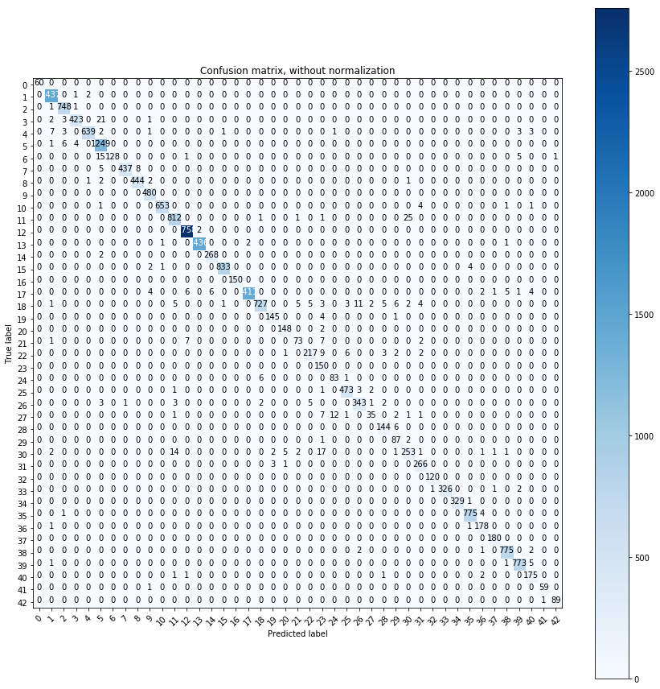

```
"\n# Plot normalized confusion matrix\nplt.figure(figsize=(12,12))\nplot_confusion_matrix(cnf_matrix, classes=class_names, normalize=True,\n                      title='Normalized confusion matrix')\n\nplt.show()\n"
```

```python
#Confusion Matrix
#http://scikit-learn.org/stable/auto_examples/model_selection/plot_confusion_matrix.html
import itertools

def plot_confusion_matrix(cm, classes,
                          normalize=False,
                          title='Confusion matrix',
                          cmap=plt.cm.Blues):
    """
    This function prints and plots the confusion matrix.
    Normalization can be applied by setting `normalize=True`.
    """
    plt.imshow(cm, interpolation='nearest', cmap=cmap)
    plt.title(title)
    plt.colorbar()
    tick_marks = np.arange(len(classes))
    plt.xticks(tick_marks, classes, rotation=45)
    plt.yticks(tick_marks, classes)

    if normalize:
        cm = cm.astype('float') / cm.sum(axis=1)[:, np.newaxis]
        print("Normalized confusion matrix")
    else:
        print('Confusion matrix, without normalization')

    print(cm)

    thresh = cm.max() / 2.
    for i, j in itertools.product(range(cm.shape[0]), range(cm.shape[1])):
        plt.text(j, i, cm[i, j],
                 horizontalalignment="center",
                 color="white" if cm[i, j] > thresh else "black")

    plt.tight_layout()
    plt.ylabel('True label')
    plt.xlabel('Predicted label')

# Compute confusion matrix
np.set_printoptions(precision=2)

class_names = np.unique(y_test_labels)

# Plot non-normalized confusion matrix
plt.figure(figsize=(12,12))
plot_confusion_matrix(cnf_matrix, classes=class_names,
                      title='Confusion matrix, without normalization')
plt.show()

"""
# Plot normalized confusion matrix
plt.figure(figsize=(12,12))
plot_confusion_matrix(cnf_matrix, classes=class_names, normalize=True,
                      title='Normalized confusion matrix')

plt.show()
"""
```

### Output Top 5 Softmax Probabilities For Each Image Found on the Web

For each of the new images, print out the model's softmax probabilities to show the **certainty** of the model's predictions (limit the output to the top 5 probabilities for each image). [`tf.nn.top_k`](https://www.tensorflow.org/versions/r0.12/api_docs/python/nn.html#top_k) could prove helpful here.

The example below demonstrates how tf.nn.top_k can be used to find the top k predictions for each image.

`tf.nn.top_k` will return the values and indices (class ids) of the top k predictions. So if k=3, for each sign, it'll return the 3 largest probabilities (out of a possible 43) and the correspoding class ids.

Take this numpy array as an example. The values in the array represent predictions. The array contains softmax probabilities for five candidate images with six possible classes. `tk.nn.top_k` is used to choose the three classes with the highest probability:

```
# (5, 6) array
a = np.array([[ 0.24879643,  0.07032244,  0.12641572,  0.34763842,  0.07893497,
         0.12789202],
       [ 0.28086119,  0.27569815,  0.08594638,  0.0178669 ,  0.18063401,
         0.15899337],
       [ 0.26076848,  0.23664738,  0.08020603,  0.07001922,  0.1134371 ,
         0.23892179],
       [ 0.11943333,  0.29198961,  0.02605103,  0.26234032,  0.1351348 ,
         0.16505091],
       [ 0.09561176,  0.34396535,  0.0643941 ,  0.16240774,  0.24206137,
         0.09155967]])
```

Running it through `sess.run(tf.nn.top_k(tf.constant(a), k=3))` produces:

```
TopKV2(values=array([[ 0.34763842,  0.24879643,  0.12789202],
       [ 0.28086119,  0.27569815,  0.18063401],
       [ 0.26076848,  0.23892179,  0.23664738],
       [ 0.29198961,  0.26234032,  0.16505091],
       [ 0.34396535,  0.24206137,  0.16240774]]), indices=array([[3, 0, 5],
       [0, 1, 4],
       [0, 5, 1],
       [1, 3, 5],
       [1, 4, 3]], dtype=int32))
```

Looking just at the first row we get `[ 0.34763842, 0.24879643, 0.12789202]`, you can confirm these are the 3 largest probabilities in `a`. You'll also notice `[3, 0, 5]` are the corresponding indices.

```python
### Print out the top five softmax probabilities for the predictions on the German traffic sign images found on the web.
### Feel free to use as many code cells as needed.
import tensorflow as tf
with tf.Session() as sess:
    tf_values, tf_indices = tf.nn.top_k(y_proba, k=5, sorted=True, name=None)
    values = sess.run(tf_values)
    top_k = sess.run(tf_indices)

print("top_k values: \n", values)
print('----------------')
print("top_k Labels: \n", top_k)
print('----------------')
print("True Labels: \n" , y_test_web)
```

```
top_k values:
 [[  9.99391675e-01   5.84567490e-04   2.15245982e-05   2.17780234e-06
    2.00570760e-08]
 [  1.00000000e+00   1.33244458e-20   4.49897598e-21   1.81665950e-24
    1.64727238e-26]
 [  9.99896765e-01   1.02913495e-04   2.86526245e-07   3.14541566e-08
    7.41763161e-12]
 [  1.00000000e+00   3.91166888e-15   1.64971278e-18   1.56341207e-19
    2.99166541e-20]
 [  1.00000000e+00   1.62501054e-10   1.26754524e-10   2.22384229e-11
    7.17719590e-12]
 [  9.99309421e-01   6.35637494e-04   4.46369704e-05   6.54357837e-06
    3.77708375e-06]
 [  1.00000000e+00   9.65624506e-15   7.36611953e-15   7.21786082e-15
    6.83216987e-15]
 [  4.57880110e-01   3.47759604e-01   1.48092717e-01   4.62670140e-02
    6.13828831e-07]
 [  9.99998689e-01   1.29381044e-06   2.67978155e-08   9.62738445e-10
    4.96938012e-11]
 [  9.99796450e-01   2.02029129e-04   1.32836806e-06   1.40770368e-07
    6.93063527e-08]
 [  7.57896185e-01   8.70252028e-02   7.41005987e-02   6.49442077e-02
    1.54783269e-02]]
----------------
top_k Labels:
 [[ 8  5  0  4  1]
 [ 1  0  4  2  5]
 [ 2  1  5 11 40]
 [20 26 11 31 25]
 [14  1  4  5 13]
 [ 5  1  2  3  6]
 [17 33  3  5 10]
 [ 5  3  2  6  9]
 [ 4  1  0  2 39]
 [ 1  0  4  9  2]
 [28 23 29 18 30]]
----------------
True Labels:
 [ 8  1  2 20 14  5 17  3  4  0 28]
```

```python
#strings = ["%.2f" % number for number in values[i]]

for i in range(11):
    print("True Label %d: \t %d" % (y_test_web[i], y_test_web[i]))
    print("Top-5 Labels: \t%s" % str(top_k[i]))
    print("Top-5 Probab: \t%s" % ["%.3f" % number for number in values[i]])
    print('---------------------------------------------------------------')
```

```
True Label 8: 	 8
Top-5 Labels: 	[8 5 0 4 1]
Top-5 Probab: 	['0.999', '0.001', '0.000', '0.000', '0.000']
---------------------------------------------------------------
True Label 1: 	 1
Top-5 Labels: 	[1 0 4 2 5]
Top-5 Probab: 	['1.000', '0.000', '0.000', '0.000', '0.000']
---------------------------------------------------------------
True Label 2: 	 2
Top-5 Labels: 	[ 2  1  5 11 40]
Top-5 Probab: 	['1.000', '0.000', '0.000', '0.000', '0.000']
---------------------------------------------------------------
True Label 20: 	 20
Top-5 Labels: 	[20 26 11 31 25]
Top-5 Probab: 	['1.000', '0.000', '0.000', '0.000', '0.000']
---------------------------------------------------------------
True Label 14: 	 14
Top-5 Labels: 	[14  1  4  5 13]
Top-5 Probab: 	['1.000', '0.000', '0.000', '0.000', '0.000']
---------------------------------------------------------------
True Label 5: 	 5
Top-5 Labels: 	[5 1 2 3 6]
Top-5 Probab: 	['0.999', '0.001', '0.000', '0.000', '0.000']
---------------------------------------------------------------
True Label 17: 	 17
Top-5 Labels: 	[17 33  3  5 10]
Top-5 Probab: 	['1.000', '0.000', '0.000', '0.000', '0.000']
---------------------------------------------------------------
True Label 3: 	 3
Top-5 Labels: 	[5 3 2 6 9]
Top-5 Probab: 	['0.458', '0.348', '0.148', '0.046', '0.000']
---------------------------------------------------------------
True Label 4: 	 4
Top-5 Labels: 	[ 4  1  0  2 39]
Top-5 Probab: 	['1.000', '0.000', '0.000', '0.000', '0.000']
---------------------------------------------------------------
True Label 0: 	 0
Top-5 Labels: 	[1 0 4 9 2]
Top-5 Probab: 	['1.000', '0.000', '0.000', '0.000', '0.000']
---------------------------------------------------------------
True Label 28: 	 28
Top-5 Labels: 	[28 23 29 18 30]
Top-5 Probab: 	['0.758', '0.087', '0.074', '0.065', '0.015']
---------------------------------------------------------------
```

## Step 4: Visualize the Neural Network's State with Test Images

This Section is not required to complete but acts as an additional excersise for understaning the output of a neural network's weights. While neural networks can be a great learning device they are often referred to as a black box. We can understand what the weights of a neural network look like better by plotting their feature maps. After successfully training your neural network you can see what it's feature maps look like by plotting the output of the network's weight layers in response to a test stimuli image. From these plotted feature maps, it's possible to see what characteristics of an image the network finds interesting. For a sign, maybe the inner network feature maps react with high activation to the sign's boundary outline or to the contrast in the sign's painted symbol.

Provided for you below is the function code that allows you to get the visualization output of any tensorflow weight layer you want. The inputs to the function should be a stimuli image, one used during training or a new one you provided, and then the tensorflow variable name that represents the layer's state during the training process, for instance if you wanted to see what the LeNet lab's feature maps looked like for it's second convolutional layer you could enter conv2 as the tf_activation variable.

For an example of what feature map outputs look like, check out NVIDIA's results in their paper [End-to-End Deep Learning for Self-Driving Cars](https://devblogs.nvidia.com/parallelforall/deep-learning-self-driving-cars/) in the section Visualization of internal CNN State. NVIDIA was able to show that their network's inner weights had high activations to road boundary lines by comparing feature maps from an image with a clear path to one without. Try experimenting with a similar test to show that your trained network's weights are looking for interesting features, whether it's looking at differences in feature maps from images with or without a sign, or even what feature maps look like in a trained network vs a completely untrained one on the same sign image.

[figure not shown]

Your output should look something like this (above)

```python
# get the symbolic outputs of each "key" layer (we gave them unique names).
layer_dict = dict([(layer.name, layer) for layer in model.layers])
print(layer_dict)
print(model.layers)
tf_layer = model.get_layer(name='conv2d_1')
print(tf_layer)
```

```
{'max_pooling2d_2': <keras.layers.pooling.MaxPooling2D object at 0x7f4a2633b828>, 'dense_2': <keras.layers.core.Dense object at 0x7f4a31323240>, 'flatten_1': <keras.layers.core.Flatten object at 0x7f4a312b3ac8>, 'dropout_3': <keras.layers.core.Dropout object at 0x7f4a2ec06358>, 'conv2d_2': <keras.la…
[<keras.layers.convolutional.Conv2D object at 0x7f4a2633b5c0>, <keras.layers.pooling.MaxPooling2D object at 0x7f4a263fa7b8>, <keras.layers.core.Dropout object at 0x7f4a263fac18>, <keras.layers.convolutional.Conv2D object at 0x7f4a2633b668>, <keras.layers.pooling.MaxPooling2D object at 0x7f4a2633b828…
<keras.layers.convolutional.Conv2D object at 0x7f4a2633b5c0>
```

```python
#Get TF Seesion and Tf Graph from Keras API
from keras import backend as K
session = K.get_session()
graph = K.get_session().graph
print(graph)
print(session)
session.graph_def
```

```
<tensorflow.python.framework.ops.Graph object at 0x7f4a2633b358>
<tensorflow.python.client.session.Session object at 0x7f4a315b9e10>
```

[output not shown]

[output cut: 12355 more lines]

[output not shown]

```python
### Visualize your network's feature maps here.
### Feel free to use as many code cells as needed.

# image_input: the test image being fed into the network to produce the feature maps
# tf_activation: should be a tf variable name used during your training procedure that represents the calculated state of a specific weight layer
# activation_min/max: can be used to view the activation contrast in more detail, by default matplot sets min and max to the actual min and max values of the output
# plt_num: used to plot out multiple different weight feature map sets on the same block, just extend the plt number for each new feature map entry

def outputFeatureMap(image_input, tf_activation, activation_min=-1, activation_max=-1 ,plt_num=1):
    # Here make sure to preprocess your image_input in a way your network expects
    # with size, normalization, ect if needed
    # image_input =
    # Note: x should be the same name as your network's tensorflow data placeholder variable
    # If you get an error tf_activation is not defined it maybe having trouble accessing the variable from inside a function
    activation = tf_activation.eval(session=session,feed_dict={conv2d_1_input : image_input})
    featuremaps = activation.shape[3]
    plt.figure(plt_num, figsize=(15,15))
    for featuremap in range(featuremaps):
        plt.subplot(6,8, featuremap+1) # sets the number of feature maps to show on each row and column
        plt.title('FeatureMap ' + str(featuremap)) # displays the feature map number
        if activation_min != -1 & activation_max != -1:
            plt.imshow(activation[0,:,:, featuremap], interpolation="nearest", vmin =activation_min, vmax=activation_max, cmap="gray")
        elif activation_max != -1:
            plt.imshow(activation[0,:,:, featuremap], interpolation="nearest", vmax=activation_max, cmap="gray")
        elif activation_min !=-1:
            plt.imshow(activation[0,:,:, featuremap], interpolation="nearest", vmin=activation_min, cmap="gray")
        else:
            plt.imshow(activation[0,:,:, featuremap], interpolation="nearest", cmap="gray")
```

```python
#Load an image
image_input = X_test_web[0]

#Get Variable by Name from the TF Graph
conv2d_1 = tf.get_collection(tf.GraphKeys.VARIABLES, "conv2d_1")[0]
conv2d_1_value = session.run(conv2d_1)
#conv2d_1
```

```
WARNING:tensorflow:VARIABLES collection name is deprecated, please use GLOBAL_VARIABLES instead; VARIABLES will be removed after 2017-03-02.
```

```python
#conv2d_1
tf_activation = conv2d_1
outputFeatureMap(image_input=image_input, tf_activation=tf_activation)
```

[output not shown]

### Project Writeup

Once you have completed the code implementation, document your results in a project writeup using this [template](https://github.com/udacity/CarND-Traffic-Sign-Classifier-Project/blob/master/writeup_template.md) as a guide. The writeup can be in a markdown or pdf file.